# Benchmarking STAR Testing - Overhang Testing

Samantha Sevilla

4//2022

## Background

In this benchmarking experiment, STAR was compared to NOVOAlign, currently utilized in our iCLIP pipeline. STAR version 2.7.8a was used (https://github.com/alexdobin/STAR/releases).

For each read, an alignment was assessed for any gaps, with two possible scenarios:

1. alignment—gap—alignment
2. alignment—gap–insertion/deletion—alignment

For all reads that match outcome #1, reads were counts. For gaps with reads larger than 100, overhang and parent were assigned to the alignments as follows:

3. overhang: the smaller length of the two alignments
4. parent: the larger length of the two alignments

Ratios were calculated for each read that met this criterion. For example #5 would have a ratio of 2/70, #6 would have a ratio of 2/70, and #7 would not be included due to the gap being <100.

5. alignment1(N=2)—gap(N=100)—alignment2(N=70)
6. alignment3(N=70)—gap(N=100)—alignment4(N=2)
7. alignment3(N=70)—gap(N=10)—alignment4(N=2)

For reads with N>2 gaps, each gap was assessed individually. For example #8 would have 2 gaps assessed, example #9 would have 3 gaps assessed and example #10 would have 1 gap assessed as gap2 does not meet the 100 threshold requirement

8. alignment1(N=2)—gap1(N=100)—alignment2(N=70)—gap2(N=100)—alignment4(N=2)
9. alignment3(N=70)—gap1(N=100)—alignment4(N=2)–gap2(N=100)—alignment4(N=2)–gap3(N=100)—alignment4(N=2)
10. alignment3(N=70)—gap1(N=100)—alignment4(N=2)–gap2(N=50)—alignment4(N=2)

Testing for this round included reviewing the annotated junction overhang minimum (17 alignSJDBoverhangMin minimum overhang for annotated junctions) between 2 and 12. Genes included in this data were a subset of reads for Rnu6, Sptan1, sympk, Gm24204 (10 reads per location) and all genes in GAPDH and ACTB.

# Variations Summary

|  | Alignment Flag | Description |
| --- | --- | --- |
| 1 | outFilterMismatchNoverReadLmax | max number of mismatches per pair relative to read length: for 2x100b, max number of mis- |
| matches is 0.04*200=8 for the paired read |  |  |
| 2 | outFilterMismatchNmax | alignment will be output only if it has no more mismatches than this value. |
| 3 | outFilterMultimapNmax | max number of multiple alignments allowed for a read: if exceeded, the read is considered unmapped |
| 4 | outSJfilterReads | which reads to consider for collapsed splice junctions output |
| 5 | outSJfilterCountTotalMin | minimum total (multi-mapping+unique) read count per junctionfor: (1) non-canonical motifs, (2) GT/AG and CT/AC motif, (3) GC/AG andCT/GC motif, (4) AT/AC and GT/AT motif. -1 means no output for thatmo… |
| 6 | alignEndsType | type of read ends alignment; fully extend only the 5p of the read1, all other ends: local alignment |
| 7 | outSAMunmapped | output of unmapped reads in the SAM format |
| 8 | outSAMattributes | a string of desired SAM attributes, in the order desired for the output SAM |
| 9 | outFilterType | keep only those reads that contain junctions that passed filtering into SJ.out.tab |
| 10 | outFilterScoreMin | alignment will be output only if its score is higher than or equal to this value. |
| 11 | outFilterMultimapScoreRange | the score range below the maximum score for multimapping alignments |
| 12 | sjdbScore | extra alignment score for alignments that cross database junctions |
| 13 | outSJfilterOverhangMin | minimum overhang length for splice junctions on both sides for: (1)non-canonical motifs, (2) GT/AG and CT/AC motif, (3) GC/AG and CT/GCmotif, (4) AT/AC and GT/AT motif. -1 means no output for that mot… |
| 14 | alignIntronMax | maximum intron length |
| 15 | outFilterMatchNmin | alignment will be output only if the number of matched bases is higher |
| than or equal to this value. |  |  |
| 16 | outFilterMatchNminOverLread | sam as outFilterMatchNmin, but normalized to the read length (sum of |
| mates’ lengths for paired-end reads). |  |  |
| 17 | alignSJDBoverhangMin | minimum overhang for annotated junctions |
| 18 | alignSJoverhangMin | minimum overhang for unannotated junctions |
| 30 | winAnchorMultimapNmax | max number of loci anchors are allowed to map to |
| 31 | seedPerReadNmax | max number of seeds per read |
| 32 | seedPerWindowNmax | max number of seeds per window |
| 33 | alignWindowsPerReadNmax | max number of windows per read |
| 34 | alignTranscriptsPerReadNmax | max number of different alignments per read to consider |
| 35 | seedMultimapNmax | only pieces that map fewer than this value are utilized in the stitching procedure |
| 36 | seedNoneLociPerWindow | max number of one seed loci per window |

|  | Alignment Flag | clipfinal_2 | clipfinal_3 | clipfinal_4 | clipfinal_5 | clipfinal_6 | clipfinal_7 | clipfinal_8 | clipfinal_9 | clipfinal_10 | clipfinal_11 | clipfinal_12 |
| --- | --- | --- | --- | --- | --- | --- | --- | --- | --- | --- | --- | --- |
| 1 | outFilterMismatchNoverReadLmax | 0.04 | 0.04 | 0.04 | 0.04 | 0.04 | 0.04 | 0.04 | 0.04 | 0.04 | 0.04 | 0.04 |
| 2 | outFilterMismatchNmax | 999 | 999 | 999 | 999 | 999 | 999 | 999 | 999 | 999 | 999 | 999 |
| 3 | outFilterMultimapNmax | 10000 | 10000 | 10000 | 10000 | 10000 | 10000 | 10000 | 10000 | 10000 | 10000 | 10000 |
| 4 | outSJfilterReads | All | All | All | All | All | All | All | All | All | All | All |
| 5 | outSJfilterCountTotalMin | 3 1 1 1 | 3 1 1 1 | 3 1 1 1 | 3 1 1 1 | 3 1 1 1 | 3 1 1 1 | 3 1 1 1 | 3 1 1 1 | 3 1 1 1 | 3 1 1 1 | 3 1 1 1 |
| 6 | alignEndsType | Local | Local | Local | Local | Local | Local | Local | Local | Local | Local | Local |
| 7 | outSAMunmapped | None | None | None | None | None | None | None | None | None | None | None |
| 8 | outSAMattributes | All | All | All | All | All | All | All | All | All | All | All |
| 9 | outFilterType | Normal | Normal | Normal | Normal | Normal | Normal | Normal | Normal | Normal | Normal | Normal |
| 10 | outFilterScoreMin | 0 | 0 | 0 | 0 | 0 | 0 | 0 | 0 | 0 | 0 | 0 |
| 11 | outFilterMultimapScoreRange | 0 | 0 | 0 | 0 | 0 | 0 | 0 | 0 | 0 | 0 | 0 |
| 12 | sjdbScore | 2 | 2 | 2 | 2 | 2 | 2 | 2 | 2 | 2 | 2 | 2 |
| 13 | outSJfilterOverhangMin | 30 12 12 12 | 30 12 12 12 | 30 12 12 12 | 30 12 12 12 | 30 12 12 12 | 30 12 12 12 | 30 12 12 12 | 30 12 12 12 | 30 12 12 12 | 30 12 12 12 | 30 12 12 12 |
| 14 | alignIntronMax | 50000 | 50000 | 50000 | 50000 | 50000 | 50000 | 50000 | 50000 | 50000 | 50000 | 50000 |
| 15 | outFilterMatchNmin | 15 | 15 | 15 | 15 | 15 | 15 | 15 | 15 | 15 | 15 | 15 |
| 16 | outFilterMatchNminOverLread | 0.9 | 0.9 | 0.9 | 0.9 | 0.9 | 0.9 | 0.9 | 0.9 | 0.9 | 0.9 | 0.9 |
| 17 | alignSJDBoverhangMin | 2 | 3 | 4 | 5 | 6 | 7 | 8 | 9 | 10 | 11 | 12 |
| 18 | alignSJoverhangMin | 5 | 5 | 5 | 5 | 5 | 5 | 5 | 5 | 5 | 5 | 5 |
| 30 | winAnchorMultimapNmax | 10000 | 10000 | 10000 | 10000 | 10000 | 10000 | 10000 | 10000 | 10000 | 10000 | 10000 |
| 31 | seedPerReadNmax | 10000 | 10000 | 10000 | 10000 | 10000 | 10000 | 10000 | 10000 | 10000 | 10000 | 10000 |
| 32 | seedPerWindowNmax | 10000 | 10000 | 10000 | 10000 | 10000 | 10000 | 10000 | 10000 | 10000 | 10000 | 10000 |
| 33 | alignWindowsPerReadNmax | 10000 | 10000 | 10000 | 10000 | 10000 | 10000 | 10000 | 10000 | 10000 | 10000 | 10000 |
| 34 | alignTranscriptsPerReadNmax | 10000 | 10000 | 10000 | 10000 | 10000 | 10000 | 10000 | 10000 | 10000 | 10000 | 10000 |
| 35 | seedMultimapNmax | 10000 | 10000 | 10000 | 10000 | 10000 | 10000 | 10000 | 10000 | 10000 | 10000 | 10000 |
| 36 | seedNoneLociPerWindow | 20 | 20 | 20 | 20 | 20 | 20 | 20 | 20 | 20 | 20 | 20 |

# Alignment

Alignment statistics were generated for each version type, including a comparison between the total number of reads uniquely mapped to those that were unmapped, and the total number of reads unique mapped and those that were multimapped.

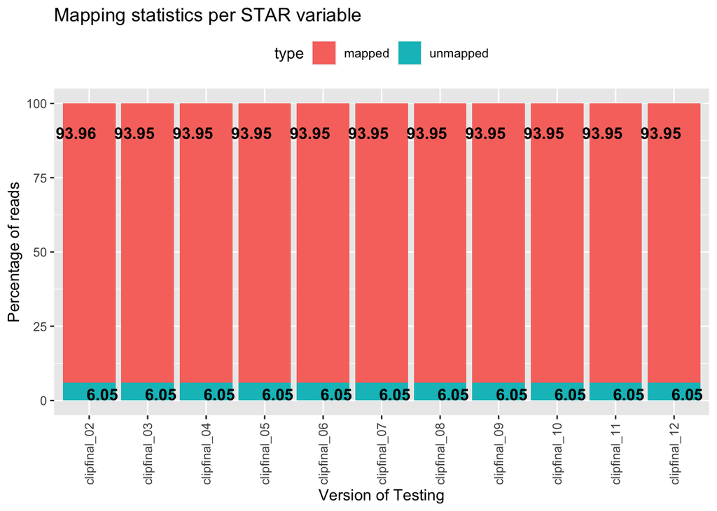

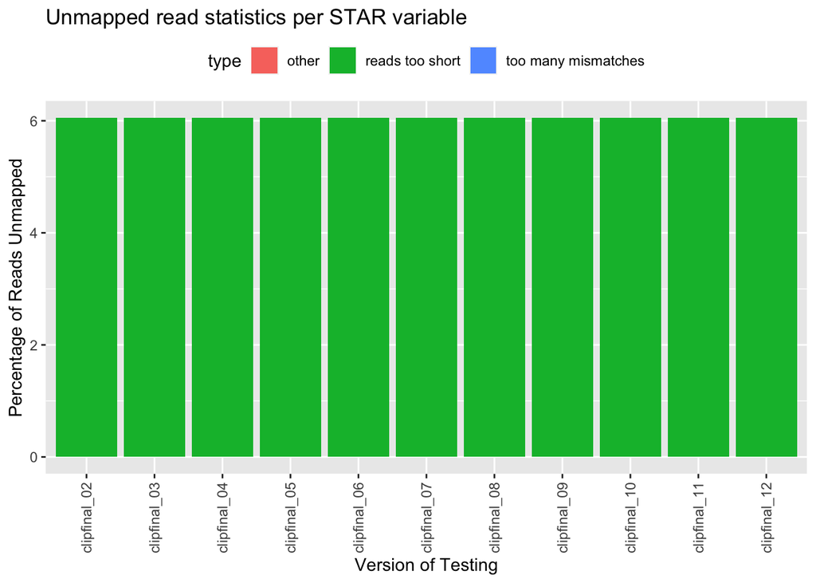

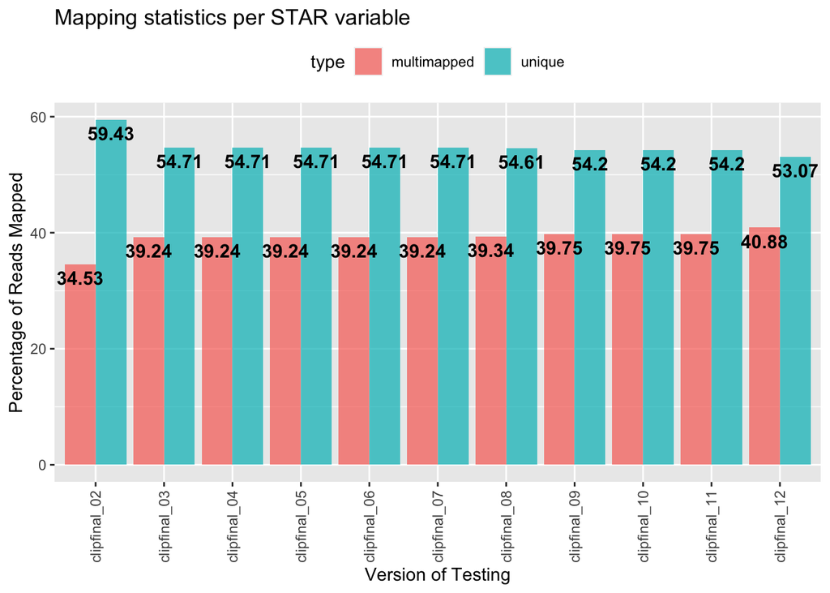

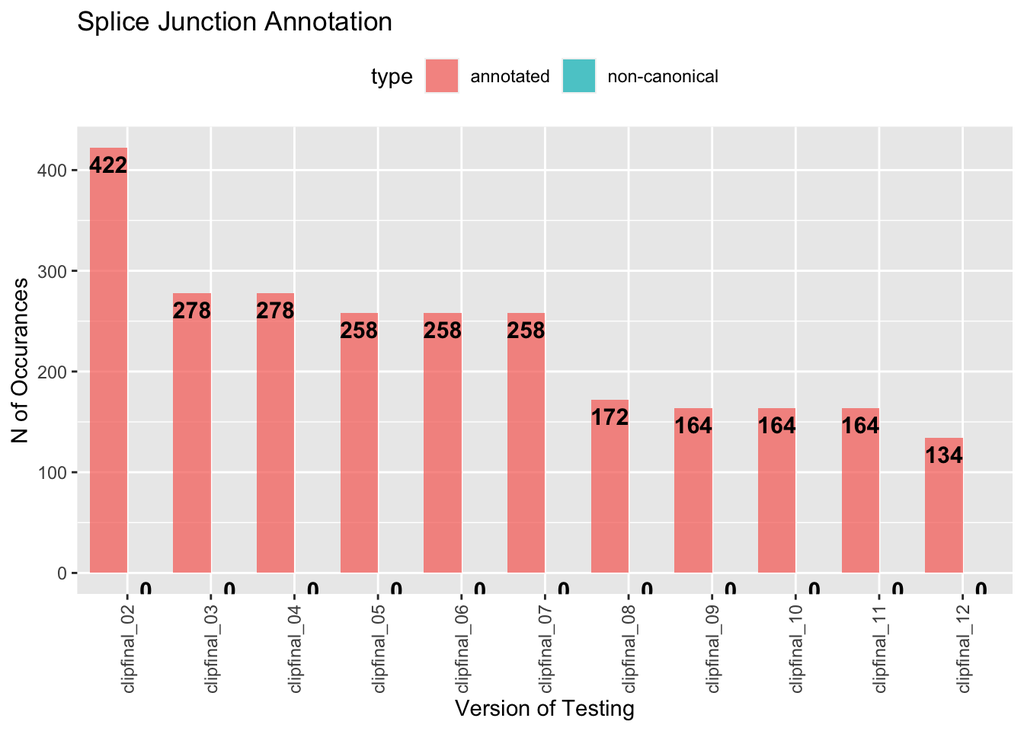

# Number of Gaps

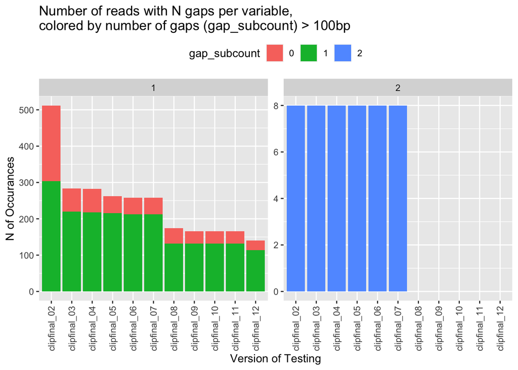

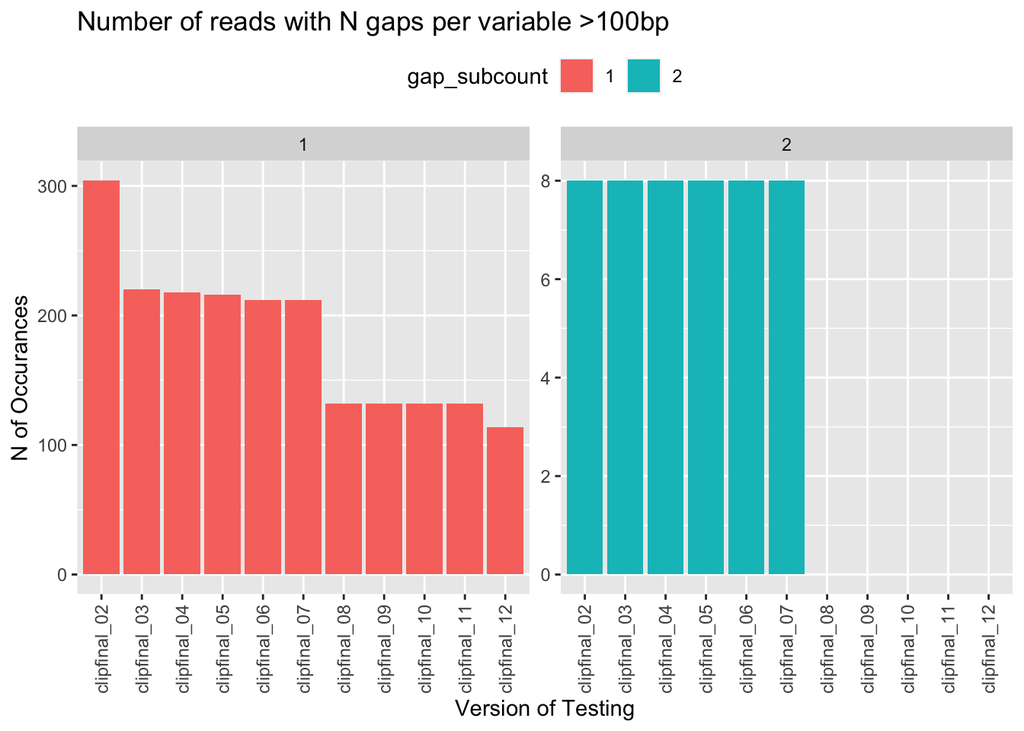

The data table includes counts of all reads with at least one gap > 100 bp.

|  | gap_1 | gap_2 | gap_total |
| --- | --- | --- | --- |
| clipfinal_02 | 304 | 8 | 312 |
| clipfinal_03 | 220 | 8 | 228 |
| clipfinal_04 | 218 | 8 | 226 |
| clipfinal_05 | 216 | 8 | 224 |
| clipfinal_06 | 212 | 8 | 220 |
| clipfinal_07 | 212 | 8 | 220 |
| clipfinal_08 | 132 | 0 | 132 |
| clipfinal_09 | 132 | 0 | 132 |
| clipfinal_10 | 132 | 0 | 132 |
| clipfinal_11 | 132 | 0 | 132 |

[output cut: 1 more lines]

# Gap Features

## Summary Tables

Summary table of alignment variation by the length of overhang or length of gap. Values indicate the number of times this feature was observed. Only gaps >100bp, with overhang/parent ratios <.50 are considered.

|  | id | 2 | 4 | 5 | 7 | 11 | 12 | 13 | 15 | 17 | 19 | totals |
| --- | --- | --- | --- | --- | --- | --- | --- | --- | --- | --- | --- | --- |
| 9 | clipfinal_10 | 0 | 0 | 0 | 0 | 14 | 4 | 36 | 28 | 8 | 22 | 112 |
| 10 | clipfinal_11 | 0 | 0 | 0 | 0 | 14 | 4 | 36 | 28 | 8 | 22 | 112 |
| 11 | clipfinal_12 | 0 | 0 | 0 | 0 | 0 | 0 | 36 | 28 | 0 | 22 | 86 |
| 1 | clipfinal_2 | 84 | 2 | 4 | 82 | 22 | 4 | 36 | 28 | 8 | 22 | 292 |
| 2 | clipfinal_3 | 0 | 2 | 4 | 82 | 22 | 4 | 36 | 28 | 8 | 22 | 208 |
| 3 | clipfinal_4 | 0 | 0 | 4 | 82 | 22 | 4 | 36 | 28 | 8 | 22 | 206 |
| 4 | clipfinal_5 | 0 | 0 | 2 | 82 | 22 | 4 | 36 | 28 | 8 | 22 | 204 |
| 5 | clipfinal_6 | 0 | 0 | 0 | 80 | 22 | 4 | 36 | 28 | 8 | 22 | 200 |
| 6 | clipfinal_7 | 0 | 0 | 0 | 80 | 22 | 4 | 36 | 28 | 8 | 22 | 200 |
| 7 | clipfinal_8 | 0 | 0 | 0 | 0 | 14 | 4 | 36 | 28 | 8 | 22 | 112 |

[output cut: 1 more lines]

|  | id | [0-1,000) | [1,000-100,00) |
| --- | --- | --- | --- |
| 9 | clipfinal_10 | 126 | 14 |
| 10 | clipfinal_11 | 126 | 14 |
| 11 | clipfinal_12 | 100 | 14 |
| 1 | clipfinal_2 | 294 | 26 |
| 2 | clipfinal_3 | 210 | 26 |
| 3 | clipfinal_4 | 208 | 26 |
| 4 | clipfinal_5 | 208 | 24 |
| 5 | clipfinal_6 | 206 | 22 |
| 6 | clipfinal_7 | 206 | 22 |
| 7 | clipfinal_8 | 126 | 14 |

[output cut: 1 more lines]

## Summary Plots

### Overhang length

Summary plot of ratios of overhang/parent alignment (see above for definitions) by the number of times they occur within the alignment variation. Only ratios under 0.5 are shown.

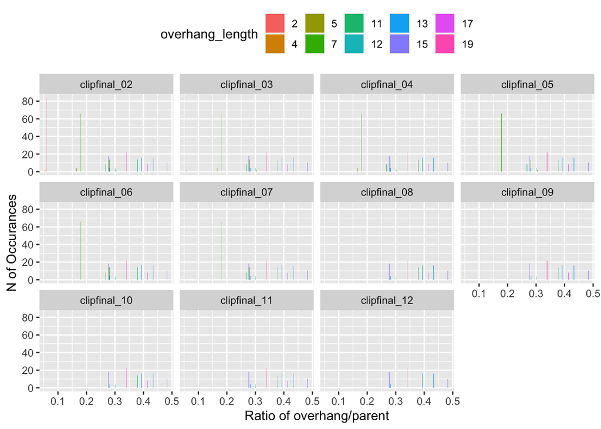

### Gap length

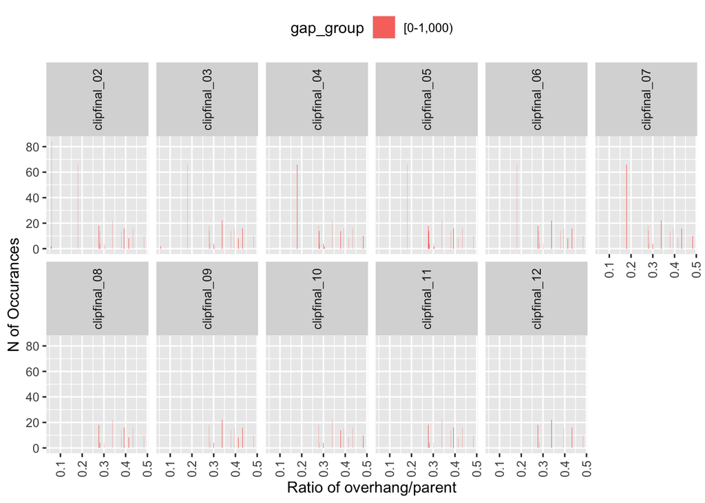

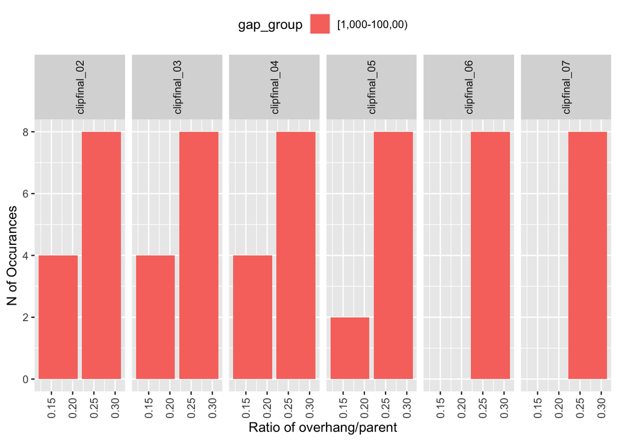